# INTRODUCTION

This notebook aims to give some light to understanding better the effects of your ML models. It is true that it is nearly impossible to understand what most ML models do just by looking at their algorithms. Even for regression models it is difficult to really get to the bottom of all possible details (for example, if you try to predict house prices and you have 5*number_bedrooms -4*number bathrooms... do you need to take away bathrooms from a house?? -- btw, typically effect of multi-collinearity).

## Aim

Anyway, the idea is to answer questions like:

- What features in the data did the model think are most important?
- For any single prediction from a model, how did each feature in the data affect that particular prediction
- How does each feature affect the model's predictions in a big-picture sense (what is its typical effect when considered over a large number of possible predictions?).

## Why might we want to do this??

### Debugging

Given the frequency and potentially distastrous consequences of bugs, debugging is one of the most valuable skills in data science. Understanding the patterns a model is finding will help you identify when those are at odds with your knowledge of the real world, and this is typically the first step in tracking down bugs. Do the features picked up as most important make sense? Have you done some weird pre-processing that has made the data do something funny? Is your data just pure garbage?

### Informing Feature Engineering

Feature engineering is usually the most effective way to improve model accuracy. Feature engineering usually involves repeatedly creating new features using transformations of your raw data or features you have previously created. Sometimes you can go through this process using nothing but intuition about the underlying topic. But you'll need more direction when you have 100s of raw features or when you lack background knowledge about the topic you are working on.

A Kaggle competition to predict loan defaults gives an extreme example. This competition had 100s of raw features. For privacy reasons, the features had names like f1, f2, f3 rather than common English names. This simulated a scenario where you have little intuition about the raw data. One competitor found that the difference between two of the features, specifically f527 - f528, created a very powerful new feature. Models including that difference as a feature were far better than models without it. But how might you think of creating this variable when you start with hundreds of variables?

The techniques we will learn would make it transparent that f527 and f528 are important features, and that their role is tightly entangled. This will direct you to consider transformations of these two variables, and likely find the "golden feature" of f527 - f528.

### Directing Future Data Collection

You have little control over datasets you download online (you can do a lot of data quality checking and choose what you use or not, but most probably you will have little control in the generation of that dataset). Collecting new types of data can be expensive or inconvenient, so we might only want to do this if we know it will be worthwhile. For example, we might have a sample dataset that we test, and by using the techniques in the notebook, we might decide that it is worthwhile spending X amount of money to pay a third party provider for this data or not.

### Informing Human Decision-Making

Some decisions are made automatically by models. Amazon doesn't have humans (or elves) scurry to decide what to show you whenever you go to their website. But many important decisions are made by humans. For these decisions, insights can be more valuable than predictions.

### Building Trust

Many people won't assume they can trust your model for important decisions without verifying some basic facts. This is a smart precaution given the frequency of data errors. In practice, showing insights that fit their general understanding of the problem will help build trust, even among people with little deep knowledge of data science.

# Permutation importance -- What features have the biggest impact on predictions?

## How does it work?

[figure not shown]

Our data includes useful features (height at age 10), features with little predictive power (socks owned), as well as some other features we won't focus on in this explanation. So let's assume we build a model using some of the mentioned features. **Permutation importance is calculated after a model has been fitted. So we won't change the model or change what predictions we'd get for a given value of height, sock-count, etc.**

Instead we will ask the following question: If I randomly shuffle a single column of the validation data, leaving the target and all other columns in place, how would that affect the accuracy of predictions in that now-shuffled data?

[figure not shown]

Randomly re-ordering a single column should cause less accurate predictions, since the resulting data no longer corresponds to anything observed in the real world. Model accuracy especially suffers if we shuffle a column that the model relied on heavily for predictions. In this case, shuffling height at age 10 would cause terrible predictions. If we shuffled socks owned instead, the resulting predictions wouldn't suffer nearly as much.

### Process summary

- Get a trained model
- Shuffle the values in a single column, make predictions using the resulting dataset.
- Use these predictions and the true target values to calculate how much the loss function suffered from shuffling. That performance deterioration measures the importance of the variable you just shuffled.
- Return the data to the original order (undoing the shuffle from step 2.) Now repeat step 2 with the next column in the dataset, until you have calculated the importance of each column.

## Code!

- We are going to build a super simple model to predict whether a football team will get one of their players as "Man of the Match" using some football stats.
- We are not going to focus on hyper tuning models or feature engineering or anything like that. The idea is to understand how to use **feature permutation**

```python
# Required modules
import numpy as np
import pandas as pd
from sklearn.model_selection import train_test_split
from sklearn.ensemble import RandomForestClassifier
```

```python
# Read data from csv
data = pd.read_csv('./data/FIFA_2018_Statistics.csv')
data.head()
```

|  | Date | Team | Opponent | Goal Scored | Ball Possession % | Attempts | On-Target | Off-Target | Blocked | Corners | ... | Yellow Card | Yellow & Red | Red | Man of the Match | 1st Goal | Round | PSO | Goals in PSO | Own goals | Own goal Time |
| --- | --- | --- | --- | --- | --- | --- | --- | --- | --- | --- | --- | --- | --- | --- | --- | --- | --- | --- | --- | --- | --- |
| 0 | 14-06-2018 | Russia | Saudi Arabia | 5 | 40 | 13 | 7 | 3 | 3 | 6 | ... | 0 | 0 | 0 | Yes | 12 | Group Stage | No | 0 | NaN | NaN |
| 1 | 14-06-2018 | Saudi Arabia | Russia | 0 | 60 | 6 | 0 | 3 | 3 | 2 | ... | 0 | 0 | 0 | No | NaN | Group Stage | No | 0 | NaN | NaN |
| 2 | 15-06-2018 | Egypt | Uruguay | 0 | 43 | 8 | 3 | 3 | 2 | 0 | ... | 2 | 0 | 0 | No | NaN | Group Stage | No | 0 | NaN | NaN |
| 3 | 15-06-2018 | Uruguay | Egypt | 1 | 57 | 14 | 4 | 6 | 4 | 5 | ... | 0 | 0 | 0 | Yes | 89 | Group Stage | No | 0 | NaN | NaN |
| 4 | 15-06-2018 | Morocco | Iran | 0 | 64 | 13 | 3 | 6 | 4 | 5 | ... | 1 | 0 | 0 | No | NaN | Group Stage | No | 0 | 1 | 90 |

5 rows × 27 columns

```python
# Variable assignments
y = (data['Man of the Match'] == "Yes")  # Convert from string "Yes"/"No" to binary
feature_names = [i for i in data.columns if data[i].dtype in [np.int64]] #Just getting the numeric variables
X = data[feature_names]
feature_names
```

```
['Goal Scored',
 'Ball Possession %',
 'Attempts',
 'On-Target',
 'Off-Target',
 'Blocked',
 'Corners',
 'Offsides',
 'Free Kicks',
 'Saves',
 'Pass Accuracy %',
 'Passes',
 'Distance Covered (Kms)',
 'Fouls Committed',
 'Yellow Card',
 'Yellow & Red',
 'Red',
 'Goals in PSO']
```

```python
# Model training
train_X, val_X, train_y, val_y = train_test_split(X, y, random_state=1)
my_model = RandomForestClassifier(random_state=0).fit(train_X, train_y)
```

### eli5 library usage

```python
import eli5
from eli5.sklearn import PermutationImportance

perm = PermutationImportance(my_model, random_state=1).fit(val_X, val_y)
eli5.show_weights(perm, feature_names = val_X.columns.tolist())
```

| Weight | Feature |
| --- | --- |
| 0.0750 ± 0.1159 | Goal Scored |
| 0.0625 ± 0.0791 | Corners |
| 0.0437 ± 0.0500 | Distance Covered (Kms) |
| 0.0375 ± 0.0729 | On-Target |
| 0.0375 ± 0.0468 | Free Kicks |
| 0.0187 ± 0.0306 | Blocked |
| 0.0125 ± 0.0750 | Pass Accuracy % |
| 0.0125 ± 0.0500 | Yellow Card |
| 0.0063 ± 0.0468 | Saves |
| 0.0063 ± 0.0250 | Offsides |
| 0.0063 ± 0.1741 | Off-Target |
| 0.0000 ± 0.1046 | Passes |
| 0 ± 0.0000 | Red |
| 0 ± 0.0000 | Yellow & Red |
| 0 ± 0.0000 | Goals in PSO |
| -0.0312 ± 0.0884 | Fouls Committed |
| -0.0375 ± 0.0919 | Attempts |
| -0.0500 ± 0.0500 | Ball Possession % |

The first number in each row shows how much model performance decreased with a random shuffling (in this case, using "accuracy" as the performance metric). Like most things in data science, there is some randomness to the exact performance change from a shuffling a column. We measure the amount of randomness in our permutation importance calculation by repeating the process with multiple shuffles. The number after the ± measures how performance varied from one-reshuffling to the next.

You'll occasionally see negative values for permutation importances. In those cases, the predictions on the shuffled (or noisy) data happened to be more accurate than the real data. This happens when the feature didn't matter (should have had an importance close to 0), but random chance caused the predictions on shuffled data to be more accurate. This is more common with small datasets, like the one in this example, because there is more room for luck/chance.

In our example, the most important feature was Goals scored. Totally sensible.

## Another example: predicting taxi fares

```python
# Modules
import pandas as pd
from sklearn.ensemble import RandomForestRegressor
from sklearn.linear_model import LinearRegression
from sklearn.model_selection import train_test_split
```

```python
# Data read
data = pd.read_csv('./data/taxi.csv', nrows=50000)
data.head()
```

|  | key | fare_amount | pickup_datetime | pickup_longitude | pickup_latitude | dropoff_longitude | dropoff_latitude | passenger_count |
| --- | --- | --- | --- | --- | --- | --- | --- | --- |
| 0 | 2009-06-15 17:26:21.0000001 | 4.5 | 2009-06-15 17:26:21 UTC | -73.844311 | 40.721319 | -73.841610 | 40.712278 | 1 |
| 1 | 2010-01-05 16:52:16.0000002 | 16.9 | 2010-01-05 16:52:16 UTC | -74.016048 | 40.711303 | -73.979268 | 40.782004 | 1 |
| 2 | 2011-08-18 00:35:00.00000049 | 5.7 | 2011-08-18 00:35:00 UTC | -73.982738 | 40.761270 | -73.991242 | 40.750562 | 2 |
| 3 | 2012-04-21 04:30:42.0000001 | 7.7 | 2012-04-21 04:30:42 UTC | -73.987130 | 40.733143 | -73.991567 | 40.758092 | 1 |
| 4 | 2010-03-09 07:51:00.000000135 | 5.3 | 2010-03-09 07:51:00 UTC | -73.968095 | 40.768008 | -73.956655 | 40.783762 | 1 |

```python
# Assigning variables
# Remove data with extreme outlier coordinates or negative fares
data = data.query('pickup_latitude > 40.7 and pickup_latitude < 40.8 and ' +
                  'dropoff_latitude > 40.7 and dropoff_latitude < 40.8 and ' +
                  'pickup_longitude > -74 and pickup_longitude < -73.9 and ' +
                  'dropoff_longitude > -74 and dropoff_longitude < -73.9 and ' +
                  'fare_amount > 0'
                  )

y = data.fare_amount

base_features = ['pickup_longitude',
                 'pickup_latitude',
                 'dropoff_longitude',
                 'dropoff_latitude',
                 'passenger_count']

X = data[base_features]
```

```python
# Data split
train_X, val_X, train_y, val_y = train_test_split(X, y, random_state=1)
```

```python
train_X.describe()
```

|  | pickup_longitude | pickup_latitude | dropoff_longitude | dropoff_latitude | passenger_count |
| --- | --- | --- | --- | --- | --- |
| count | 23466.000000 | 23466.000000 | 23466.000000 | 23466.000000 | 23466.000000 |
| mean | -73.976827 | 40.756931 | -73.975359 | 40.757434 | 1.662320 |
| std | 0.014625 | 0.018206 | 0.015930 | 0.018659 | 1.290729 |
| min | -73.999999 | 40.700013 | -73.999999 | 40.700020 | 0.000000 |
| 25% | -73.987964 | 40.744901 | -73.987143 | 40.745756 | 1.000000 |
| 50% | -73.979629 | 40.758076 | -73.978588 | 40.758542 | 1.000000 |
| 75% | -73.967797 | 40.769602 | -73.966459 | 40.770406 | 2.000000 |
| max | -73.900062 | 40.799952 | -73.900062 | 40.799999 | 6.000000 |

Intuitively, it seems obvious that as a customer, we will pay more the longer your ride is. In this case, "long", would be determined by differences between pickup and dropoff points. I don't believe passenger count would have a big difference in taxi fare (it might reduce the price you pay as you share, but the total taxi fare shoudn't really change much). Let's build a model and check what it's picking up.

```python
first_model = RandomForestRegressor(n_estimators=30, random_state=1).fit(train_X, train_y)
```

```python
# Permutations
perm = PermutationImportance(first_model, random_state=1).fit(val_X, val_y)
eli5.show_weights(perm, feature_names = val_X.columns.tolist())
```

| Weight | Feature |
| --- | --- |
| 0.8474 ± 0.0185 | dropoff_latitude |
| 0.8267 ± 0.0263 | pickup_latitude |
| 0.6229 ± 0.0559 | pickup_longitude |
| 0.5384 ± 0.0305 | dropoff_longitude |
| -0.0029 ± 0.0020 | passenger_count |

- And just as I had expected, passenger count doesn't really have any effect on this total taxi fare, but the dropoff and pickup locations do.
- Now, still there is something to stand-out. Latitude figures seem to be more important than longitude figures. My only hypothesis with this are:
  - Taxi rides along the x-axis (longitude) tend to be shorter than taxi rides along the y-axis (latitude).
  - Maybe better roads on longitude rides which might decrease the time spent to travel per unit distance.
  - Maybe also, different tolls that the taxi drivers need to pay heading north or south.

### Creating new features thanks to the provided insight

Checking the results above, I think it would be super interesting to derive a travelled distance measure or something similar, and re-train the model.

```python
# create new features
data['abs_lon_change'] = abs(data.dropoff_longitude - data.pickup_longitude)
data['abs_lat_change'] = abs(data.dropoff_latitude - data.pickup_latitude)

features_2  = ['pickup_longitude',
               'pickup_latitude',
               'dropoff_longitude',
               'dropoff_latitude',
               'abs_lat_change',
               'abs_lon_change']

X = data[features_2]
new_train_X, new_val_X, new_train_y, new_val_y = train_test_split(X, y, random_state=1)
new_train_X.head()
```

|  | pickup_longitude | pickup_latitude | dropoff_longitude | dropoff_latitude | abs_lat_change | abs_lon_change |
| --- | --- | --- | --- | --- | --- | --- |
| 37925 | -73.998695 | 40.726192 | -73.977974 | 40.730652 | 0.004459 | 0.020721 |
| 21594 | -73.985115 | 40.756692 | -73.985735 | 40.744192 | 0.012500 | 0.000620 |
| 39549 | -73.961988 | 40.776092 | -73.974067 | 40.783107 | 0.007015 | 0.012079 |
| 11953 | -73.953661 | 40.766884 | -73.948705 | 40.773745 | 0.006861 | 0.004956 |
| 5521 | -73.957168 | 40.765680 | -73.969532 | 40.758050 | 0.007630 | 0.012364 |

```python
second_model = RandomForestRegressor(n_estimators=30, random_state=1).fit(new_train_X, new_train_y)
```

```python
perm2 = PermutationImportance(second_model, random_state=1).fit(new_val_X, new_val_y)
eli5.show_weights(perm2, feature_names = new_val_X.columns.tolist())
```

| Weight | Feature |
| --- | --- |
| 0.5783 ± 0.0295 | abs_lat_change |
| 0.4467 ± 0.0509 | abs_lon_change |
| 0.0858 ± 0.0333 | pickup_latitude |
| 0.0735 ± 0.0101 | dropoff_longitude |
| 0.0733 ± 0.0113 | dropoff_latitude |
| 0.0613 ± 0.0063 | pickup_longitude |

- Great, so the derived features we generated do have a bigger impact than the ones we initially had.
- Still, the location coordinates affect fares.

One thing to stand out from the input data is that the distance measures are pretty small (0-0.1 range) compared to the rest of the variables (typical example where you created and used a feature that was 100X as large for these features, and used that larger feature for training and importance calculations).

- Do you think this could explain why those coordinates had larger permutation importance values in this case?
- Would this change the outputted permutation importance values?

The scale of features does not affect permutation importance per se. The only reason that rescaling a feature would affect permutation importance is indirectly, if rescaling helped or hurt the ability of the particular learning method we're using to make use of that feature. That won't happen with tree based models, like the Random Forest used here (if you are familiar with Ridge Regression, you might be able to think of how that would be affected). That said, the absolute change in distance features in this example, have high importance because they capture total distance traveled, which is the primary determinant of taxi fares...It is not an artifact of the feature magnitude.

# Partial dependence plots - how does a feature affect predictions

While feature importance shows *what* variables most affect predictions, **partial dependence plots show *how* a feature affects predictions.**

If you are familiar with linear or logistic regression models, partial dependence plots can be interepreted similarly to the coefficients in those models. Though, partial dependence plots on sophisticated models can capture more complex patterns than coefficients from simple models.

## How does it work?

Like permutation importance, partial dependence plots are calculated after a model has been fit. The model is fit on real data that has not been artificially manipulated in any way.

To see how partial plots separate out the effect of each feature, we start by considering a single row of data:

- In our soccer example, teams may differ in many ways. How many passes they made, shots they took, goals they scored, etc. At first glance, it seems difficult to disentangle the effect of these features.
- For example, a row of data might represent a team that had the ball 50% of the time, made 100 passes, took 10 shots and scored 1 goal.

Once the model has been built:

- We repeatedly alter the value for one variable to make a series of predictions. Basically, pick that row of data and alter the value for 1 variable.
- For example, we could predict the outcome if the team had the ball only 40% of the time. We then predict with them having the ball 50% of the time. Then predict again for 60%. And so on.
- We trace out predicted outcomes (on the vertical axis) as we move from small values of ball possession to large values (on the horizontal axis).

In this description, we used only a single row of data. Interactions between features may cause the plot for a single row to be atypical. So, we repeat that mental experiment with multiple rows from the original dataset, and we plot the average predicted outcome on the vertical axis.

## Code!

```python
# Modules
import numpy as np
import pandas as pd
from sklearn.model_selection import train_test_split
from sklearn.ensemble import RandomForestClassifier
from sklearn.tree import DecisionTreeClassifier
```

```python
# Read data
data = pd.read_csv('./data/FIFA_2018_Statistics.csv')
data.head()
```

|  | Date | Team | Opponent | Goal Scored | Ball Possession % | Attempts | On-Target | Off-Target | Blocked | Corners | ... | Yellow Card | Yellow & Red | Red | Man of the Match | 1st Goal | Round | PSO | Goals in PSO | Own goals | Own goal Time |
| --- | --- | --- | --- | --- | --- | --- | --- | --- | --- | --- | --- | --- | --- | --- | --- | --- | --- | --- | --- | --- | --- |
| 0 | 14-06-2018 | Russia | Saudi Arabia | 5 | 40 | 13 | 7 | 3 | 3 | 6 | ... | 0 | 0 | 0 | Yes | 12 | Group Stage | No | 0 | NaN | NaN |
| 1 | 14-06-2018 | Saudi Arabia | Russia | 0 | 60 | 6 | 0 | 3 | 3 | 2 | ... | 0 | 0 | 0 | No | NaN | Group Stage | No | 0 | NaN | NaN |
| 2 | 15-06-2018 | Egypt | Uruguay | 0 | 43 | 8 | 3 | 3 | 2 | 0 | ... | 2 | 0 | 0 | No | NaN | Group Stage | No | 0 | NaN | NaN |
| 3 | 15-06-2018 | Uruguay | Egypt | 1 | 57 | 14 | 4 | 6 | 4 | 5 | ... | 0 | 0 | 0 | Yes | 89 | Group Stage | No | 0 | NaN | NaN |
| 4 | 15-06-2018 | Morocco | Iran | 0 | 64 | 13 | 3 | 6 | 4 | 5 | ... | 1 | 0 | 0 | No | NaN | Group Stage | No | 0 | 1 | 90 |

5 rows × 27 columns

```python
# Variable assignments
y = (data['Man of the Match'] == "Yes")  # Convert from string "Yes"/"No" to binary
feature_names = [i for i in data.columns if data[i].dtype in [np.int64]] #Just getting the numeric variables
X = data[feature_names]
feature_names
```

```
['Goal Scored',
 'Ball Possession %',
 'Attempts',
 'On-Target',
 'Off-Target',
 'Blocked',
 'Corners',
 'Offsides',
 'Free Kicks',
 'Saves',
 'Pass Accuracy %',
 'Passes',
 'Distance Covered (Kms)',
 'Fouls Committed',
 'Yellow Card',
 'Yellow & Red',
 'Red',
 'Goals in PSO']
```

```python
# Model training
train_X, val_X, train_y, val_y = train_test_split(X, y, random_state=1)
tree_model = DecisionTreeClassifier(random_state=0, max_depth=5, min_samples_split=5).fit(train_X, train_y)
```

```python
# For the sake of explanation, our first example uses a Decision Tree which you can see below.
from sklearn import tree
import graphviz

tree_graph = tree.export_graphviz(tree_model, out_file=None, feature_names=feature_names)
graphviz.Source(tree_graph)
```

[figure not shown]

### PDPBox library usage

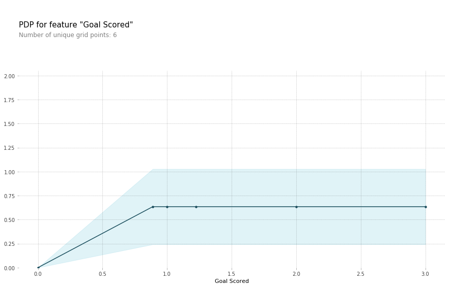

```python
from matplotlib import pyplot as plt
from pdpbox import pdp, get_dataset, info_plots

# Create the data that we will plot --> In this case we are only passing the feature Goal scored (as it appears
# to be the most important in the decisin tre)
pdp_goals = pdp.pdp_isolate(model=tree_model, dataset=val_X, model_features=feature_names, feature='Goal Scored')
pdp.pdp_plot(pdp_goals, 'Goal Scored')
plt.show()
```

A few items are worth pointing out as you interpret this plot:

- The y axis is interpreted as **change in the prediction** from what it would be predicted at the baseline or leftmost value.
- A blue shaded area indicates level of confidence
- From this particular graph, we see that scoring 1 goal substantially increases your chances of winning "Player of The Game." But extra goals beyond that appear to have little impact on predictions.

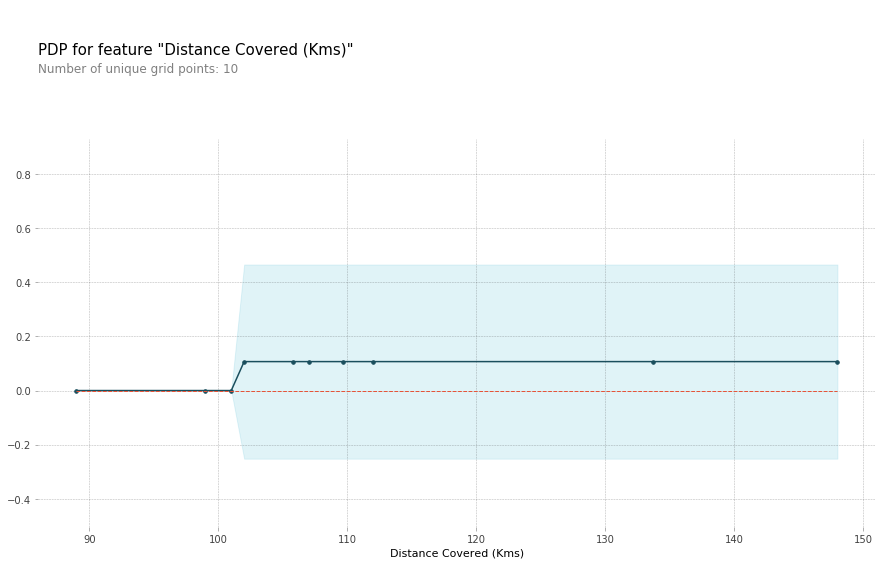

```python
# Another example
feature_to_plot = 'Distance Covered (Kms)'
pdp_dist = pdp.pdp_isolate(model=tree_model, dataset=val_X, model_features=feature_names, feature=feature_to_plot)

pdp.pdp_plot(pdp_dist, feature_to_plot)
plt.show()
```

- This graph seems too simple to represent reality. But that's because the model is so simple. You should be able to see from the decision tree above that this is representing exactly the model's structure.
- Let's build random forest, to see if we can capture any different non-linear effects.

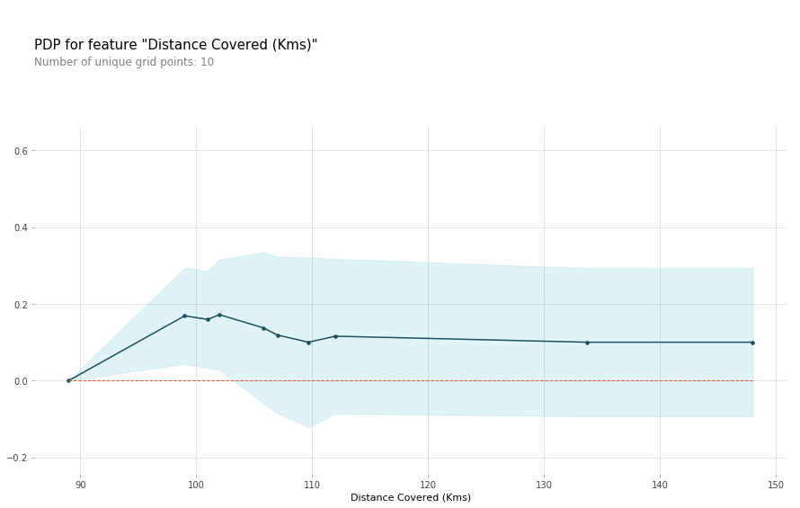

```python
# Build Random Forest model
rf_model = RandomForestClassifier(random_state=0).fit(train_X, train_y)

# Plot feature
feature_to_plot = 'Distance Covered (Kms)'
pdp_dist = pdp.pdp_isolate(model=rf_model, dataset=val_X, model_features=feature_names, feature=feature_to_plot)

pdp.pdp_plot(pdp_dist, feature_to_plot)
plt.show()
```

This model thinks you are more likely to win Player of The Game if your players run a total of 100km over the course of the game. Though running much more causes lower predictions.

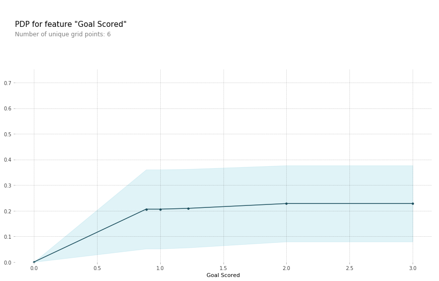

```python
# Plot feature
feature_to_plot = 'Goal Scored'
pdp_dist = pdp.pdp_isolate(model=rf_model, dataset=val_X, model_features=feature_names, feature=feature_to_plot)

pdp.pdp_plot(pdp_dist, feature_to_plot)
plt.show()
```

## Interactions between features

If you are curious about interactions between features, 2D partial dependence plots are also useful. An example may clarify what this. We will again use the Decision Tree model for this graph. It will create an extremely simple plot, but you should be able to match what you see in the plot to the tree itself.

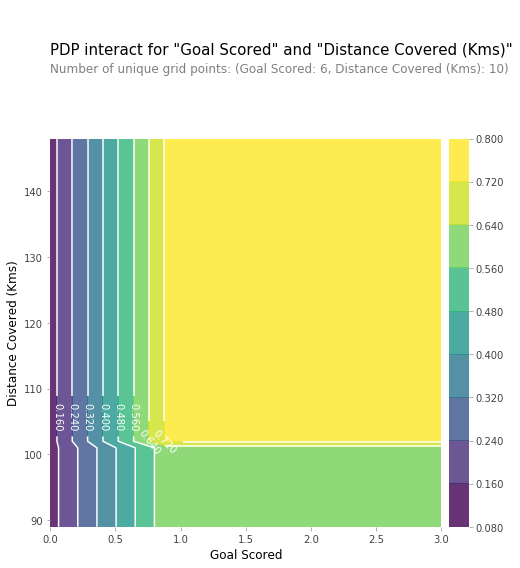

```python
# Similar to previous PDP plot except we use pdp_interact instead of pdp_isolate and pdp_interact_plot instead
# of pdp_isolate_plot
features_to_plot = ['Goal Scored', 'Distance Covered (Kms)']
inter1  =  pdp.pdp_interact(model=tree_model, dataset=val_X, model_features=feature_names
                            , features=features_to_plot)

pdp.pdp_interact_plot(pdp_interact_out=inter1, feature_names=features_to_plot, plot_type='contour')
plt.show()
```

This graph shows predictions for any combination of Goals Scored and Distance covered:

## Another example: back again to predicting taxi fares

```python
import pandas as pd
from sklearn.ensemble import RandomForestRegressor
from sklearn.linear_model import LinearRegression
from sklearn.model_selection import train_test_split

# Data manipulation code below here
data = pd.read_csv('./data/taxi.csv', nrows=50000)

# Remove data with extreme outlier coordinates or negative fares
data = data.query('pickup_latitude > 40.7 and pickup_latitude < 40.8 and ' +
                  'dropoff_latitude > 40.7 and dropoff_latitude < 40.8 and ' +
                  'pickup_longitude > -74 and pickup_longitude < -73.9 and ' +
                  'dropoff_longitude > -74 and dropoff_longitude < -73.9 and ' +
                  'fare_amount > 0'
                  )

y = data.fare_amount

base_features = ['pickup_longitude',
                 'pickup_latitude',
                 'dropoff_longitude',
                 'dropoff_latitude']

X = data[base_features]


train_X, val_X, train_y, val_y = train_test_split(X, y, random_state=1)
first_model = RandomForestRegressor(n_estimators=30, random_state=1).fit(train_X, train_y)
print("Data sample:")
data.head()
```

```
Data sample:
```

|  | key | fare_amount | pickup_datetime | pickup_longitude | pickup_latitude | dropoff_longitude | dropoff_latitude | passenger_count |
| --- | --- | --- | --- | --- | --- | --- | --- | --- |
| 2 | 2011-08-18 00:35:00.00000049 | 5.7 | 2011-08-18 00:35:00 UTC | -73.982738 | 40.761270 | -73.991242 | 40.750562 | 2 |
| 3 | 2012-04-21 04:30:42.0000001 | 7.7 | 2012-04-21 04:30:42 UTC | -73.987130 | 40.733143 | -73.991567 | 40.758092 | 1 |
| 4 | 2010-03-09 07:51:00.000000135 | 5.3 | 2010-03-09 07:51:00 UTC | -73.968095 | 40.768008 | -73.956655 | 40.783762 | 1 |
| 6 | 2012-11-20 20:35:00.0000001 | 7.5 | 2012-11-20 20:35:00 UTC | -73.980002 | 40.751662 | -73.973802 | 40.764842 | 1 |
| 7 | 2012-01-04 17:22:00.00000081 | 16.5 | 2012-01-04 17:22:00 UTC | -73.951300 | 40.774138 | -73.990095 | 40.751048 | 1 |

```python
from matplotlib import pyplot as plt
from pdpbox import pdp, get_dataset, info_plots
```

### Running PDP for all features in loop

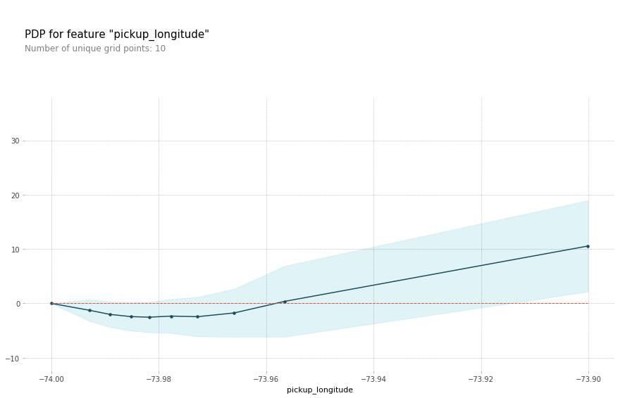

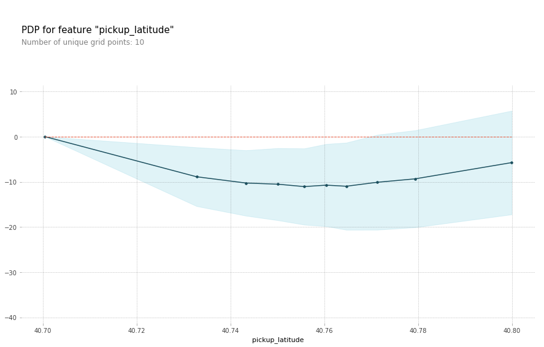

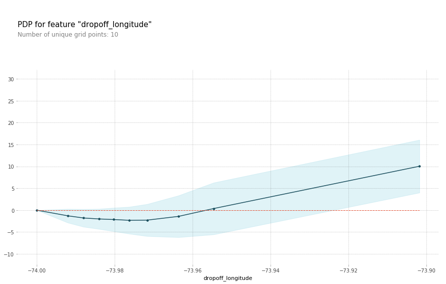

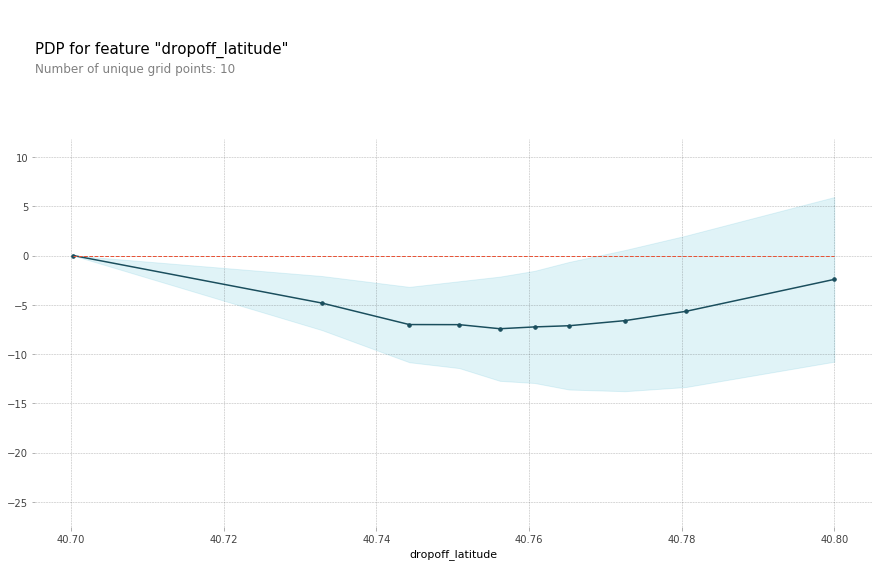

```python
for feat_name in base_features:
    pdp_dist = pdp.pdp_isolate(model=first_model, dataset=val_X,
                               model_features=base_features, feature=feat_name)
    pdp.pdp_plot(pdp_dist, feat_name)
    plt.show()
```

What can the plots mean?

- Given that we haven't added the distance metrics to this model, the Random Forest ist trying to infer distances though locations.
- In this case, what the longitude plots are telling us is that, if you are picked up in those locations that are closer to the center of the city, the distances you travel will probably be shorter ---> which means that the prediction lowers values of predicted fares compared to a baseline model.

**QUESTION:** Consider a scenario where you have only 2 predictive features, which we will call `feat_A` and `feat_B`. Both features have minimum values of -1 and maximum values of 1. The partial dependence plot for `feat_A` increases steeply over its whole range, whereas the partial dependence plot for feature B increases at a slower rate (less steeply) over its whole range. Does this guarantee that `feat_A` will have a higher permutation importance than `feat_B`. Why or why not?

**ANSWER -->** No. This doesn't guarantee feat_a is more important. For example, feat_a could have a big effect in the cases where it varies, but could have a single value 99% of the time. In that case, permuting feat_a wouldn't matter much, since most values would be unchanged.

### Interaction between features

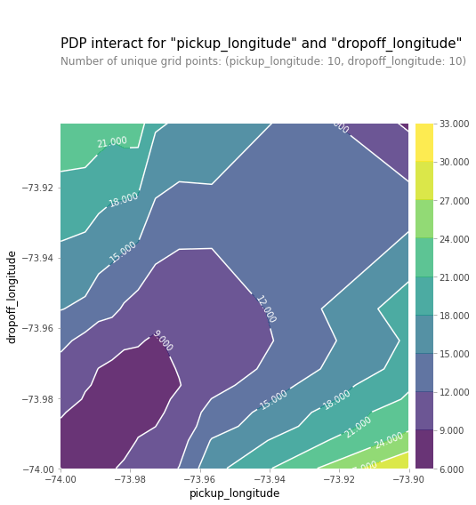

```python
inter1  =  pdp.pdp_interact(model=first_model, dataset=val_X, model_features=base_features
                            , features=['pickup_longitude', 'dropoff_longitude'])

pdp.pdp_interact_plot(pdp_interact_out=inter1, feature_names=['pickup_longitude', 'dropoff_longitude']
                      , plot_type='contour')
plt.show()
```

You should expect the plot to have contours running along a diagonal. We see that to some extent, though there are interesting caveats:

- We expect the diagonal contours because these are pairs of values where the pickup and dropoff longitudes are nearby, indicating shorter trips (controlling for other factors).
- As you get further from the central diagonal, we should expect prices to increase as the distances between the pickup and dropoff longitudes also increase.
- The surprising feature is that prices increase as you go further to the upper-right of this graph, even staying near that 45-degree line. This could be worth further investigation, though the effect of moving to the upper right of this graph is small compared to moving away from that 45-degree line.

**QUESTION:** Consider a ride starting at longitude -73.92 and ending at longitude -74. Using the graph from the last question, estimate how much money the rider would have saved if they'd started the ride at longitude -73.98 instead?

**ANSWER -->** About 15. The price decreases from slightly more than 24 to slightly more than 9.

# SHAP Values - understanding what the model is doing for an individual prediction

You've seen (and used) techniques to extract general insights from a machine learning model. But what if you want to break down how the model works for an individual prediction?

SHAP Values (an acronym from SHapley Additive exPlanations) break down a prediction to show the impact of each feature. Where could you use this?:

- A model says a bank shouldn't loan someone money, and the bank is legally required to explain the basis for each loan rejection
- A healthcare provider wants to identify what factors are driving each patient's risk of some disease so they can directly address those risk factors with targeted health interventions

## How does it work?

SHAP values interpret the impact of having a certain value for a given feature in comparison to the prediction we'd make if that feature took some baseline value.

An example is helpful, and we'll continue the football example from the permutation importance and partial dependence plots examples. In these exercises, we predicted whether a team would have a player win the Man of the Game award. We could ask:

- How much was a prediction driven by the fact that the team scored 3 goals?

But it's easier to give a concrete, numeric answer if we restate this as:

- How much was a prediction driven by the fact that the team scored 3 goals, instead of some baseline number of goals.

Of course, each team has many features. So if we answer this question for number of goals, we could repeat the process for all other features.

SHAP values do this in a way that guarantees a nice property. When we make a prediction:

**sum(SHAP values for all features) = pred_for_team - pred_for_baseline_values**

That is, the SHAP values of all features sum up to explain why my prediction was different from the baseline. This allows us to decompose a prediction in a graph like this:

[figure not shown]

**How do you interpret this?**

- We predicted 0.7, whereas the base_value is 0.4979.
- Feature values causing increased predictions are in pink, and their visual size shows the magnitude of the feature's effect.
- Feature values decreasing the prediction are in blue.
- The biggest impact comes from Goal Scored being 2. Though the ball possession value has a meaningful effect decreasing the prediction.
- If you subtract the length of the blue bars from the length of the pink bars, it equals the distance from the base value to the output. (There is some complexity to the technique, to ensure that the baseline plus the sum of individual effects adds up to the prediction (which isn't as straightforward as it sounds.) We won't go into that detail here, since it isn't critical for using the technique. This blog post has a longer theoretical explanation)

## Code!

```python
import numpy as np
import pandas as pd
from sklearn.model_selection import train_test_split
from sklearn.ensemble import RandomForestClassifier

data = pd.read_csv('./data/FIFA_2018_Statistics.csv')
y = (data['Man of the Match'] == "Yes")  # Convert from string "Yes"/"No" to binary
feature_names = [i for i in data.columns if data[i].dtype in [np.int64, np.int64]]
X = data[feature_names]
train_X, val_X, train_y, val_y = train_test_split(X, y, random_state=1)
my_model = RandomForestClassifier(random_state=0).fit(train_X, train_y)
```

Let's select row 5 and start interpreting what our prediction was and how was it broken down amongst the used features.

```python
row_to_show = 5
data_for_prediction = val_X.iloc[row_to_show]  # use 1 row of data here. Could use multiple rows if desired
data_for_prediction_array = data_for_prediction.values.reshape(1, -1)

# The team is 70% likely to have a player win the award (second value) --> lets look at the break down of it in the
# next few cells.
my_model.predict_proba(data_for_prediction_array)
```

```
array([[ 0.3,  0.7]])
```

The shap_values object below is a list with two arrays:

- The first array is the SHAP values for a negative outcome (don't win the award)
- The second array is the list of SHAP values for the positive outcome (wins the award). We typically think about predictions in terms of the prediction of a positive outcome, so we'll pull out Shap values for positive outcomes (pulling out shap_values[1].)

In addition, if you look carefully at the code where we create the SHAP values, you'll notice we reference Trees in shap.TreeExplainer(my_model). But the SHAP package has explainers for every type of model.

- *shap.DeepExplainer* works with Deep Learning models.
- *shap.KernelExplainer* works with all models, though it is slower than other Explainers and it offers an approximation rather than exact Shap values.

```python
import shap  # package used to calculate Shap values

# Create object that can calculate shap values
explainer = shap.TreeExplainer(my_model)

# Calculate Shap values
shap_values = explainer.shap_values(data_for_prediction)
```

```python
shap_values[1]
```

```
array([ 0.11623053, -0.05767237, -0.01050023,  0.05671806,  0.00056563,
       -0.02781995,  0.05009299, -0.03722792,  0.03430812,  0.03016995,
       -0.00395719,  0.01650006, -0.01940904,  0.03691749, -0.00062073,
        0.        ,  0.        ,  0.01778793])
```

```python
shap.initjs()
shap.force_plot(explainer.expected_value[1], shap_values[1], data_for_prediction)
```

**Visualization omitted, Javascript library not loaded!**  
Have you run `initjs()` in this notebook? If this notebook was from another user you must also trust this notebook (File -> Trust notebook). If you are viewing this notebook on github the Javascript has been stripped for security. If you are using JupyterLab this error is because a JupyterLab extension has not yet been written.

## Another example: Hospital re-admissions explanations

A hospital has struggled with "readmissions" where they release a patient before the patient has recovered enough, and the patient returns with health complications. The hospital wants your help identifying patients at highest risk of being readmitted. Doctors (rather than your model) will make the final decision about when to release each patient; but they hope your model will highlight issues the doctors should consider when releasing a patient.

The hospital has given you relevant patient medical information. Here is a list of columns in the data:

```python
# Read data from csv
data = pd.read_csv('./data/medical.csv')
data.columns
```

```
Index([u'time_in_hospital', u'num_lab_procedures', u'num_procedures',
       u'num_medications', u'number_outpatient', u'number_emergency',
       u'number_inpatient', u'number_diagnoses', u'race_Caucasian',
       u'race_AfricanAmerican', u'gender_Female', u'age_[70-80)',
       u'age_[60-70)', u'age_[50-60)', u'age_[80-90)', u'age_[40-50)',
       u'payer_code_?', u'payer_code_MC', u'payer_code_HM', u'payer_code_SP',
       u'payer_code_BC', u'medical_specialty_?',
       u'medical_specialty_InternalMedicine',
       u'medical_specialty_Emergency/Trauma',
       u'medical_specialty_Family/GeneralPractice',
       u'medical_specialty_Cardiology', u'diag_1_428', u'diag_1_414',
       u'diag_1_786', u'diag_2_276', u'diag_2_428', u'diag_2_250',
       u'diag_2_427', u'diag_3_250', u'diag_3_401', u'diag_3_276',
       u'diag_3_428', u'max_glu_serum_None', u'A1Cresult_None',
       u'metformin_No', u'repaglinide_No', u'nateglinide_No',
       u'chlorpropamide_No', u'glimepiride_No', u'acetohexamide_No',
       u'glipizide_No', u'glyburide_No', u'tolbutamide_No', u'pioglitazone_No',
       u'rosiglitazone_No', u'acarbose_No', u'miglitol_No', u'troglitazone_No',
       u'tolazamide_No', u'examide_No', u'citoglipton_No', u'insulin_No',
       u'glyburide-metformin_No', u'glipizide-metformin_No',
       u'glimepiride-pioglitazone_No', u'metformin-rosiglitazone_No',
       u'metformin-pioglitazone_No', u'change_No', u'diabetesMed_Yes',
       u'readmitted'],
      dtype='object')
```

Here are some quick hints at interpreting the field names:

- Your prediction target is `readmitted`
- Columns with the word `diag` indicate the diagnostic code of the illness or illnesses the patient was admitted with. For example, `diag_1_428` means the doctor said their first illness diagnosis is number "428". What illness does 428 correspond to? You could look it up in a codebook, but without more medical background it wouldn't mean anything to you anyway.
- A column names like `glimepiride_No` mean the patient did not have the medicine `glimepiride`. If this feature had a value of False, then the patient did take the drug `glimepiride`
- Features whose names begin with `medical_specialty` describe the specialty of the doctor seeing the patient. The values in these fields are all `True` or `False`.

### Build simple model

```python
import pandas as pd
from sklearn.ensemble import RandomForestClassifier
from sklearn.model_selection import train_test_split

y = data.readmitted

base_features = [c for c in data.columns if c != "readmitted"]

X = data[base_features]

train_X, val_X, train_y, val_y = train_test_split(X, y, random_state=1)
my_model = RandomForestClassifier(n_estimators=30, random_state=1).fit(train_X, train_y)
```

### Calculate and show permutation importance:

```python
import eli5
from eli5.sklearn import PermutationImportance

perm = PermutationImportance(my_model, random_state=1).fit(val_X, val_y)
eli5.show_weights(perm, feature_names = val_X.columns.tolist())
```

| Weight | Feature |
| --- | --- |
| 0.0451 ± 0.0068 | number_inpatient |
| 0.0087 ± 0.0046 | number_emergency |
| 0.0062 ± 0.0053 | number_outpatient |
| 0.0033 ± 0.0016 | payer_code_MC |
| 0.0020 ± 0.0016 | diag_3_401 |
| 0.0016 ± 0.0031 | medical_specialty_Emergency/Trauma |
| 0.0014 ± 0.0024 | A1Cresult_None |
| 0.0014 ± 0.0021 | medical_specialty_Family/GeneralPractice |
| 0.0013 ± 0.0010 | diag_2_427 |
| 0.0013 ± 0.0011 | diag_2_276 |
| 0.0011 ± 0.0022 | age_[50-60) |
| 0.0010 ± 0.0022 | age_[80-90) |
| 0.0007 ± 0.0006 | repaglinide_No |
| 0.0006 ± 0.0010 | diag_1_428 |
| 0.0006 ± 0.0022 | payer_code_SP |
| 0.0005 ± 0.0030 | insulin_No |
| 0.0004 ± 0.0028 | diabetesMed_Yes |
| 0.0004 ± 0.0021 | diag_3_250 |
| 0.0003 ± 0.0018 | diag_2_250 |
| 0.0003 ± 0.0015 | glipizide_No |
| *… 44 more …* |  |

It appears `number_inpatient` is a really important feature. The doctors would like to know more about that!!

### Calculate and show partial dependence plot:

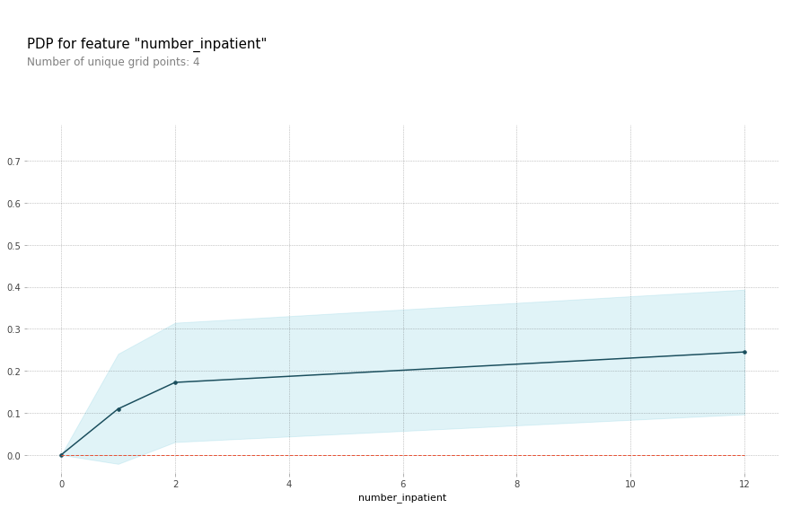

```python
from matplotlib import pyplot as plt
from pdpbox import pdp, get_dataset, info_plots

# Create the data that we will plot
pdp_goals = pdp.pdp_isolate(model=my_model, dataset=val_X, model_features=base_features, feature='number_inpatient')

# plot it
pdp.pdp_plot(pdp_goals, 'number_inpatient')
plt.show()
```

The doctors think it's a good sign that increasing the number of inpatient procedures leads to increased predictions. But they can't tell from this plot whether that change in the plot is big or small. They'd like you to create something similar for `time_in_hospital` to see how that compares.

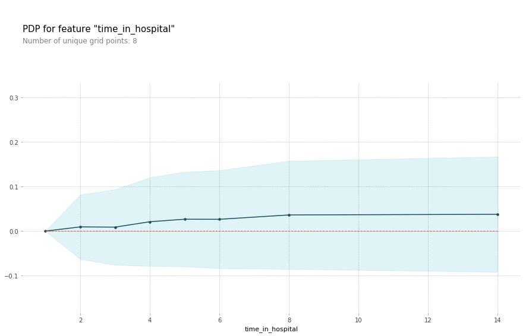

```python
from matplotlib import pyplot as plt
from pdpbox import pdp, get_dataset, info_plots

feature_name = 'time_in_hospital'
# Create the data that we will plot
my_pdp = pdp.pdp_isolate(model=my_model, dataset=val_X, model_features=val_X.columns, feature=feature_name)

# plot it
pdp.pdp_plot(my_pdp, feature_name)
plt.show()
```

- Woah! It seems like `time_in_hospital` doesn't matter at all. The difference between the lowest value on the partial dependence plot and the highest value is about 5%!!
- If that is what your model concluded, the doctors will believe it. But it seems so low. Could the data be wrong, or is your model doing something more complex than they expect?
- They'd like you to show them the raw readmission rate for each value of `time_in_hospital` to see how it compares to the partial dependence plot.

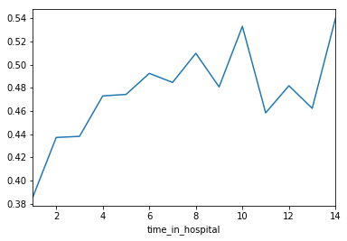

```python
# A simple pandas groupby showing the average readmission rate for each time_in_hospital.

# Do concat to keep validation data separate, rather than using all original data
all_train = pd.concat([train_X, train_y], axis=1)

all_train.groupby(['time_in_hospital']).mean().readmitted.plot()
plt.show()
```

Now the doctors are convinced you have the right data, and the model overview looked reasonable. It's time to turn this into a finished product they can use. Specifically, the hospital wants you to create a function `patient_risk_factors` that does the following

- Takes a single row with patient data (of the same format you as your raw data)
- Creates a visualization showing what features of that patient increased their risk of readmission, what features decreased it, and how much those features mattered.

It's not important to show every feature with every miniscule impact on the readmission risk. It's fine to focus on only the most important features for that patient.

```python
import shap  # package used to calculate Shap values

def patient_risk_factors(model, patient_data):
    # Create object that can calculate shap values
    explainer = shap.TreeExplainer(model)
    shap_values = explainer.shap_values(patient_data)
    shap.initjs()
    return shap.force_plot(explainer.expected_value[1], shap_values[1], patient_data)
```

```python
sample_data_for_prediction = val_X.iloc[3].astype(float)  # to test function
patient_risk_factors(my_model,sample_data_for_prediction)
```

**Visualization omitted, Javascript library not loaded!**  
Have you run `initjs()` in this notebook? If this notebook was from another user you must also trust this notebook (File -> Trust notebook). If you are viewing this notebook on github the Javascript has been stripped for security. If you are using JupyterLab this error is because a JupyterLab extension has not yet been written.

# SHAP summary plots

Permutation importance is great because it created simple numeric measures to see which features mattered to a model. This helped us make comparisons between features easily, and you can present the resulting graphs to non-technical audiences.

But it doesn't tell you how each features matter. If a feature has medium permutation importance, that could mean it has:

- a large effect for a few predictions, but no effect in general, or
- a medium effect for all predictions

SHAP summary plots give us a birds-eye view of feature importance and what is driving it. We'll walk through an example plot for the soccer data:

```python
import numpy as np
import pandas as pd
from sklearn.model_selection import train_test_split
from sklearn.ensemble import RandomForestClassifier

# Read data from csv
data = pd.read_csv('./data/FIFA_2018_Statistics.csv')
y = (data['Man of the Match'] == "Yes")  # Convert from string "Yes"/"No" to binary
feature_names = [i for i in data.columns if data[i].dtype in [np.int64, np.int64]]
X = data[feature_names]
train_X, val_X, train_y, val_y = train_test_split(X, y, random_state=1)
my_model = RandomForestClassifier(random_state=0).fit(train_X, train_y)
```

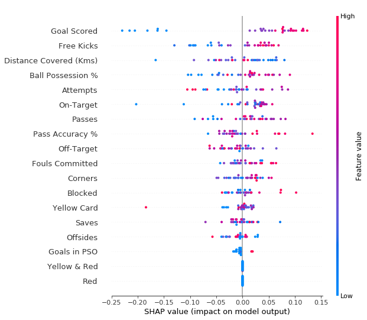

```python
import shap  # package used to calculate Shap values

# Create object that can calculate shap values
explainer = shap.TreeExplainer(my_model)

# calculate shap values. This is what we will plot.
# Calculate shap_values for all of val_X rather than a single row, to have more data for plot.
shap_values = explainer.shap_values(val_X)

# Make plot. Index of [1] is explained in text below.
shap.summary_plot(shap_values[1], val_X)
```

**This plot is made of many dots. Each dot has three characteristics:**

- Vertical location shows what feature it is depicting
- Color shows whether that feature was high or low for that row of the dataset
- Horizontal location shows whether the effect of that value caused a higher or lower prediction. For example, the point in the upper left was for a team that scored few goals, reducing the prediction by 0.25.

**Some things you should be able to easily pick out:**

- The model ignored the Red and Yellow & Red features.
- Usually Yellow Card doesn't affect the prediction, but there is an extreme case where a high value caused a much lower prediction.
- High values of Goal scored caused higher predictions, and low values caused low predictions

**The code isn't too complex. But there are a few caveats.**

- When plotting, we call shap_values[1]. For classification problems, there is a separate array of SHAP values for each possible outcome. In this case, we index in to get the SHAP values for the prediction of "True".
- Calculating SHAP values can be slow. It isn't a problem here, because this dataset is small. But you'll want to be careful when running these to plot with reasonable sized datasets. The exception is when using an xgboost model, which SHAP has some optimizations for and which is thus much faster.

This provides a great overview of the model, but we might want to delve into a single feature. That's where SHAP dependence contribution plots come into play.

# SHAP dependence contribution plots

We've previously used Partial Dependence Plots to show how a single feature impacts predictions. These are insightful and relevant for many real-world use cases. Plus, with a little effort, they can be explained to a non-technical audience.

But there's a lot they don't show. For instance, what is the distribution of effects? Is the effect of having a certain value pretty constant, or does it vary a lot depending on the values of other feaures. SHAP dependence contribution plots provide a similar insight to PDP's, but they add a lot more detail.

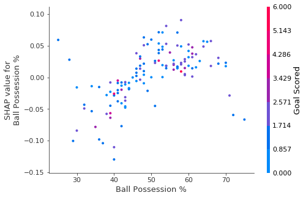

```python
import shap  # package used to calculate Shap values

# Create object that can calculate shap values
explainer = shap.TreeExplainer(my_model)

# calculate shap values. This is what we will plot.
shap_values = explainer.shap_values(X)

# make plot.
shap.dependence_plot('Ball Possession %', shap_values[1], X, interaction_index="Goal Scored")
```

Start by focusing on the shape, and we'll come back to color in a minute. Each dot represents a row of the data. The horizontal location is the actual value from the dataset, and the vertical location shows what having that value did to the prediction. The fact this slopes upward says that the more you possess the ball, the higher the model's prediction is for winning the Man of the Game award.

The spread suggests that other features must interact with Ball Possession %. For example, here we have highlighted two points with similar ball possession values. That value caused one prediction to increase, and it caused the other prediction to decrease.

[figure not shown]

For comparison, a simple linear regression would produce plots that are perfect lines, without this spread. This suggests we delve into the interactions, and the plots include color coding to help do that. While the primary trend is upward, you can visually inspect whether that varies by dot color. Consider the following very narrow example for concreteness.

[figure not shown]

These two points stand out spatially as being far away from the upward trend. They are both colored purple, indicating the team scored one goal. You can interpret this to say In general, having the ball increases a team's chance of having their player win the award. But if they only score one goal, that trend reverses and the award judges may penalize them for having the ball so much if they score that little. Outside of those few outliers, the interaction indicated by color isn't very dramatic here. But sometimes it will jump out at you.

## Another example: Hospital re-admissions

```python
import pandas as pd
from sklearn.ensemble import RandomForestClassifier
from sklearn.model_selection import train_test_split

data = pd.read_csv('./data/medical.csv')
y = data.readmitted
base_features = ['number_inpatient', 'num_medications', 'number_diagnoses', 'num_lab_procedures',
                 'num_procedures', 'time_in_hospital', 'number_outpatient', 'number_emergency',
                 'gender_Female', 'payer_code_?', 'medical_specialty_?', 'diag_1_428', 'diag_1_414',
                 'diabetesMed_Yes', 'A1Cresult_None']

# Some versions of shap package error when mixing bools and numerics
X = data[base_features].astype(float)

train_X, val_X, train_y, val_y = train_test_split(X, y, random_state=1)

# For speed, we will calculate shap values on smaller subset of the validation data
small_val_X = val_X.iloc[:150]
my_model = RandomForestClassifier(n_estimators=30, random_state=1).fit(train_X, train_y)
```

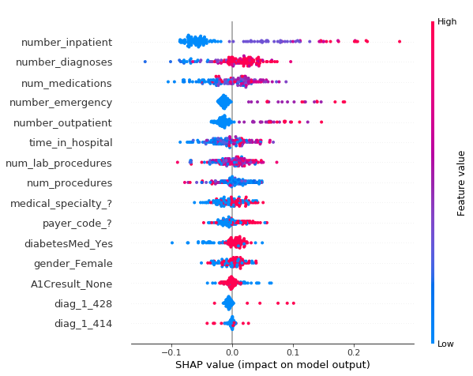

```python
explainer = shap.TreeExplainer(my_model)
shap_values = explainer.shap_values(small_val_X)

shap.summary_plot(shap_values[1], small_val_X)
```

Once we know the distribution and effects of each feature, let's ask ourselves some questions:

**QUESTION:** Which of the following features has a bigger range of effects on predictions (i.e. larger difference between most positive and most negative effect)

- `diag_1_428` or
- `payer_code_?`

**ANSWER -->** the range of diag_1_428 is wider, largely due to the few points on the far right.

**QUESTION:** Do you believe the range of effects sizes (distance between smallest effect and largest effect) is a good indication of which feature will have a higher permutation importance? Why or why not? If the **range of effect sizes** measures something different from **permutation importance**: which is a better answer for the question "Which of these two features does the model say is more important for us to understand when discussing readmission risks in the population?"

**ANSWER -->** No. The width of the effects range is not a reasonable approximation to permutation importance. For that matter, the width of the range doesn't map well to any intuitive sense of "importance" because it can be determined by just a few outliers. However if all dots on the graph are widely spread from each other, that is a reasonable indication that permutation importance is high. Because the range of effects is so sensitive to outliers, permutation importance is a better measure of what's generally important to the model.

**QUESTION:** Both `diag_1_428` and `payer_code_?` are binary variables, taking values of 0 or 1. From the graph, which do you think would typically have a bigger impact on predicted readmission risk:

- Changing `diag_1_428` from 0 to 1
- Changing `payer_code_?` from 0 to 1

**ANSWER -->** While most SHAP values of diag_1_428 are small, the few pink dots (high values of the variable, corresponding to people with that diagnosis) have large SHAP values. In other words, the pink dots for this variable are far from 0, and making someone have the higher (pink) value would increase their readmission risk significantly. In real-world terms, this diagnosis is rare, but poses a larger risk for people who have it. In contrast, payer*code*? has many values of both blue and pink, and both have SHAP values that differ meaningfully from 0. But changing payer*code*? from 0 (blue) to 1 (pink) is likely to have a smaller impact than changing diag_1_428.

**QUESTION:** Some features (like `number_inpatient`) have reasonably clear separation between the blue and pink dots. Other variables like `num_lab_procedures` have blue and pink dots jumbled together, even though the SHAP values (or impacts on prediction) aren't all 0. What do you think you learn from the fact that `num_lab_procedures` has blue and pink dots jumbled together?

--> The jumbling suggests that sometimes increasing that feature leads to higher predictions, and other times it leads to a lower prediction. Said another way, both high and low values of the feature can have both positive and negative effects on the prediction. The most likely explanation for this "jumbling" of effects is that the variable (in this case num_lab_procedures) has an interaction effect with other variables. For example, there may be some diagnoses for which it is good to have many lab procedures, and other diagnoses where suggests increased risk. We don't yet know what other feature is interacting with num_lab_procedures though we could investigate that with SHAP contribution dependence plots.

**QUESTION:** Consider the following SHAP contribution dependence plot.

[figure not shown]

- The x-axis shows `feature_of_interest` and the points are colored based on `other_feature`.
- Is there an interaction between `feature_of_interest` and `other_feature`?
- If so, does `feature_of_interest` have a more positive impact on predictions when `other_feature` is high or when `other_feature` is low?

**QUESTION:** Review the summary plot for the readmission data. Both **num_medications** and **num_lab_procedures** share that jumbling of pink and blue dots. Aside from `num_medications` having effects of greater magnitude (both more positive and more negative), it's hard to see a meaningful difference between how these two features affect readmission risk. Create the SHAP dependence contribution plots for each variable, and describe what you think is different between how these two variables affect predictions.

**ANSWER -->** Loosely speaking, num_lab_procedures looks like a cloud with little disernible pattern. It does not slope steeply up nor down at any point. It's hard to say we've learned much from that plot. At the same time, the values are not all very close to 0. So the model seems to think this is a relevant feature. One potential next step would be to explore more by coloring it with different other features to search for an interaction.

On the other hand, num_medications clearly slopes up until a value of about 20, and then it turns back down. Without more medical background, this seems a surprising phenomenon... You could do some exploration to see whether these patients have unusual values for other features too. But a good next step would be to discuss this phenomenon with domain experts (in this case, the doctors).

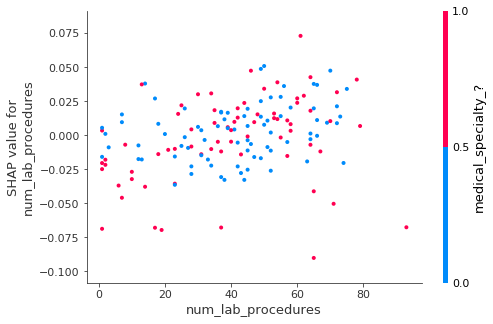

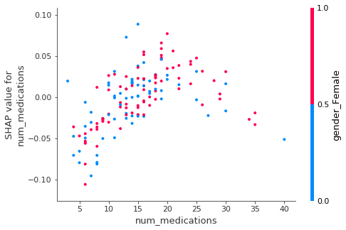

```python
shap.dependence_plot('num_lab_procedures', shap_values[1], small_val_X)
shap.dependence_plot('num_medications', shap_values[1], small_val_X)
```